# Part II - Exploration of ProsperLoan Dataset

## by Bright Obot

## Investigation Overview

> In this project we tried to answer the following questions:
> - What factors affect a loan’s outcome status?
> - What factors affects the borrower’s APR or interest rate?
> - Are there differences between loans depending on how large the original loan amount was?

> The factors we Identified for the first questions weew the amount of money borrowed and the rate of interest on the loans. The Higher the interest rate, and high loan values are likely to be past due. The employment statues vary with the borrowers Apr as seen that most Employed individuals were in current loan status. Also a higher original loan amount will tell how high the loan will be.

## Dataset Overview

> The Loan prosper dataset contained 113,937 loans with 81 variables on each loan. The main features of interest in my dataset were the borrower's interest rate (BorrowerRate) and the current loan status (LoanStatus).

# Visualization 1

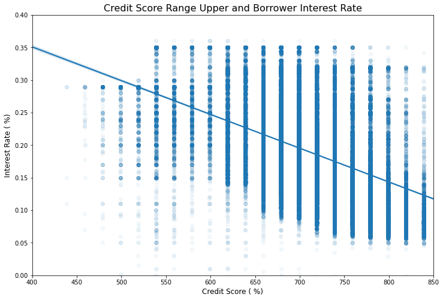

# Visualization 2

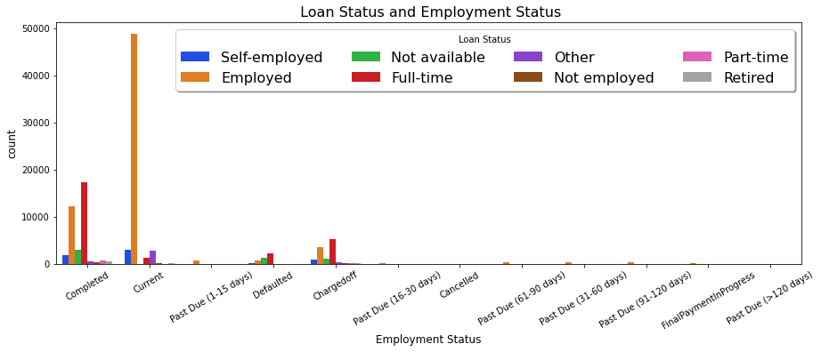

> From the Visualization, I observed that loan status are affected by employment status. Current Loan status in the employed category has the highest frequency, followed by the completed loan status, Chargeoff loan status, and then the defaulted loan status. More loans are taken by people in the employed category.

# Visualization 3

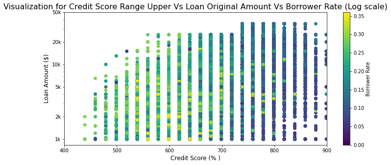

> The visualization showed that the borrower's credit score and borrowers interest rate have negative relationship. Although it is not as serous as we can imagine, there are some instances where loan amount affect on the interest rate as well.